# Starting with R and RStudio

Andrew Stewart, Email: drandrewjstewart@gmail.com, Twitter: @ajstewart_lang

# Why R and RStudio Desktop?

In this workshop I will introduce you to the language, [R](https://www.r-project.org/about.html), and [RStudio Dekstop](https://rstudio.com), the integrated development environment (IDE) that you will use to write reproducible code involving the wrangling, visualization, summary, and statistical modelling of your data. Both R and RStudio Desktop are examples of [Open Source Software](https://opensource.com/resources/what-open-source). Open Source is key to producing reproducible research as Open Source software is free and available to all.

In the video below, I’ll introduce you to R and RStudio Desktop and talk about the importance of adopting these tools in our research analysis workflows.

If you have a Google account, you can also view and download the slides in a range of formats by clicking on the image below. If you don’t have a Google account, you can download the slides in .pdf format by clicking here.

[figure not shown]

Below is a video of a great talk by J.J. Allaire, entrepreneur and founder of RStudio (and other organizations). This video is from rstudio::conf 2020 and in it J.J. talks about his journey from being a Political Scientist, how he got involved in R, and the importance of Open Source in the context of Reproducible Data Science. If you click on the image, you’ll be taken to the RStudio website where you can watch the recording. If you’re interested, you might like to look at some of the other videos on the RStudio site.

[figure not shown]

# Getting Started

In this next video I will show you how to install R (the language) and RStudio Desktop (the IDE for working with the language). You can download R from [here](https://www.stats.bris.ac.uk/R/) for a variety of platforms including Mac OS, Windows, and Ubuntu. To download free RStudio Desktop just go to [here](https://rstudio.com/products/rstudio/download/).

You can also view and download the slides in a range of formats by clicking on the image below. If you don’t have a Google account, you can download the slides in .pdf format by clicking here.

[figure not shown]

# Good Project Management

When you are doing data analysis using R, it’s important to use a sensible structure for your folders and files. As you saw in the video above, creating a new project with a .Rproj file is the easiest way to this is using RStudio Desktop. Good file management is as important as good coding style (which we’ll come to next). There’s a great paper on project management in data analysis by Greg Wilson, Jenny Bryan and others that you can read by clicking the image below.

[figure not shown]

# Good Coding Style

In the following video I’ll talk a little about good coding style. It’s important when you’re writing analysis scripts that your code is understandable by others, and by future you. If you get into the habit of good coding style early on, it will make things a lot easier in the long run - and you’ll find it easier to work collaboratively (and others will find it easier to work with you).

You can have a look at the helpful Tidyverse Style Guide [here](https://style.tidyverse.org).

If you want to make your code and data open (and you really should unless there’s a good reason not to do so), it’s important to license it properly to allow others to (re)use and remix it. For my own work, I tend to use the most permissive license that I can. My ‘go to’ licenses are the [MIT License](https://opensource.org/licenses/MIT), and the [Creative Commons License CC-BY 4.0.](https://creativecommons.org/licenses/by/4.0/)

You can use [this handy guide](https://choosealicense.com) if you need help choosing the right license for your own work.

You can also view and download the slides in a range of formats by clicking on the image below. If you don’t have a Google account, you can download the slides in .pdf format by clicking here.

[figure not shown]

# Reading in Data

One of the tasks that R learners tend to find the hardest is loading their data. In this video, I show you the two main ways we will be using in this unit to load our data. All the data we will be working with is in *rectangular* format - in other words, data with rows and columns, and with one observation per cell. I will show you how to load data that’s sitting on your own machine, and how to load data that’s sitting on a webpage.

You can also view and download the slides in a range of formats by clicking on the image below. If you don’t have a Google account, you can download the slides in .pdf format by clicking here.

[figure not shown]

# Your First R Script

You’re now going to run your first R script. We will create three visualisations of UFO sightings in the US using a database of more than 80,000 UFO sightings over the years. Before you run the code, you will need to install three packages onto your computer - they are `tidyverse`, `ggrepel`, and `patchwork`. The code for installing each packages needs to be typed into the Console in RStudio Desktop. Watch the following video to see me create the .Rproj file for this example, then install the packages before running the code.

[video not shown]

Once you have installed the packages, copy and paste the following code into your new R script. Run the code in the same way I show you in the video. Does your visualisation look like the one I generated?

```r
library(tidyverse) # load the tidyverse
library(ggrepel) # needed to ensure text labels don't overlap
library(patchwork) # needed to combine our 4 plots at the end

# read in data
ufo_sightings <- read_csv("https://raw.githubusercontent.com/rfordatascience/tidytuesday/master/data/2019/2019-06-25/ufo_sightings.csv")

# plot of top 10 US states with number of sightings in each state
plot1 <- ufo_sightings %>%
  filter(!is.na(state)) %>%
  mutate(state = str_to_upper(state)) %>%
  group_by(state) %>%
  tally() %>%
  top_n(10) %>%
  ggplot(aes(x = reorder(state, n), y = n, fill = state)) +
  geom_col() +
  coord_flip() +
  guides(fill = FALSE) +
  labs(title = "Top 10 States for UFO Sightings",
       x = NULL,
       y = NULL) +
  ylim(0, 11000) +
  theme_minimal() +
  theme(text = element_text(size = 15))

# work out the top 10 states with most UFO sightings
top_states <- ufo_sightings %>%
  filter(!is.na(state)) %>%
  group_by(state) %>%
  tally() %>%
  top_n(10) %>%
  pull(state)

# work out states within lat and long limits (i.e., exclude Alaska)
tidied_ufo <- ufo_sightings %>%
  filter(country == "us") %>%
  filter(latitude > 24 & latitude < 50)

# plot all sightings on a map of the US, with 10 top states coloured
plot2 <- tidied_ufo %>%
  ggplot(aes(x = longitude, y = latitude)) +
  geom_point(size = .5, alpha = .25) +
  theme_void() +
  coord_cartesian() +
  labs(title = "Sites of UFO Sightings in the US") +
  guides(colour = FALSE) +
  guides(fill = FALSE) +
  theme(text = element_text(size = 15))

# plot of top 10 UFO shapes spotted in California
plot3 <- tidied_ufo %>%
  filter(state == "ca") %>%
  filter(ufo_shape != "other") %>%
  filter(ufo_shape != "unknown") %>%
  group_by(ufo_shape) %>%
  tally() %>%
  top_n(10) %>%
  mutate(ufo_shape = str_to_title(ufo_shape)) %>%
  ggplot(aes(x = reorder(ufo_shape, n), y = n, fill = ufo_shape)) +
  geom_col() +
  coord_flip() +
  guides(fill = FALSE) +
  labs(title = "Top 10 UFO Shapes spotted in California",
       x = NULL,
       y = NULL) +
  theme_minimal() +
  theme(text = element_text(size = 15))

# Put plots together
my_plot <- (plot1 + plot3) / (plot2)

ggsave("ufo_plot.jpg", plot = my_plot, width = 12, height = 10)
```

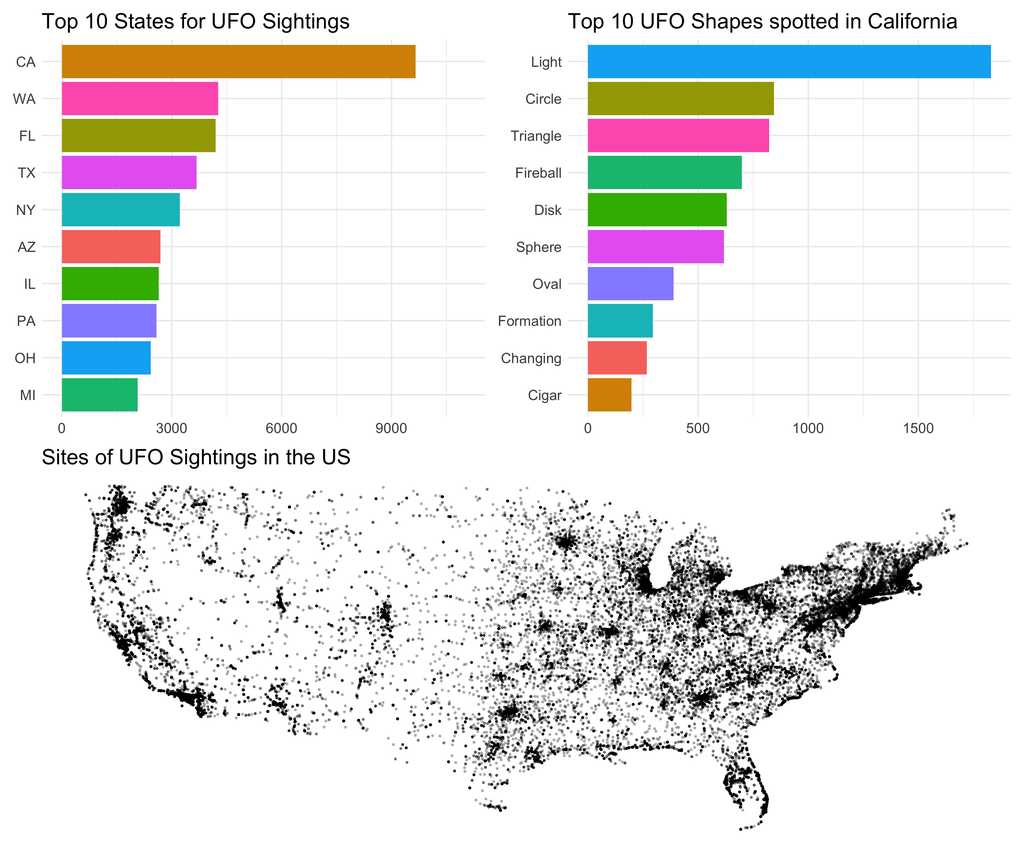